# State of existing sampling in Mbalmayo and Bouamir observatories

2024-06-04

## Mbalmayo / Bouamir / Loundoungou supersites / observatories

Two embedded permanent surveys

- Canopy trees censused by drone and field delineation.
- 1 ha permanent plot where all trees >= 10 cm at breast height.
- Plots are complementary to delineated canopy trees –> bring insights on tree assembly and dynamics.

## Mbalmayo / Bouamir / Loundoungou supersites / observatories

| site | 1 ha plots Number of plots | 1 ha plots Number of stem | 1 ha plots Number of species | Canopy observatory Number of trees | Canopy observatory Number of species |
| --- | --- | --- | --- | --- | --- |
| Bouamir | 8 | 3689 | 218 | 1354 | 136 |
| Mbalmayo | 14 | 6865 | 243 | 2053 | 146 |

## (re)censuses

- In Mbalmayo, first three plots established in 06-2021. Recensus for 3 plots in April 2024
- Scheduled recensus in April 2025.
- In Bouamir, first four plots established in 12-2018. Recensus in June 2022.
- Scheduled three to four additional plots in July 2024.

## Herbarium specimens

Taxonomic identification is difficult for most species. To confirm or improve field identification, herbarium specimens should be collected and identified in herbarium.

For both Bouamir and Mbalmayo, herbarium specimens are collected. 610 specimens are linked to individuals in plots, representing at least 220 different species.

We take on average 4 to 5 photos of each specimen, hence at least 2440 photos are available for feeding Pl@ntnet.

## Addtional information : weather stations

- Mbalmayo : station at **ca.** 15 km to the observatory since September 2023
- Bouamir : station within the observatory since 2017, thanks to collaboration with UCLA managing the station.
- Data (temperature, rainfall, wind, solar radiation, evapotranspiration) measured every 15 minutes.

## Addtional information : weather stations

Small aside : monthly mininmum and maximum temperature and rainfall and anomalies since 2017 in Bouamir (Vincent Deblauwe, April 2024).

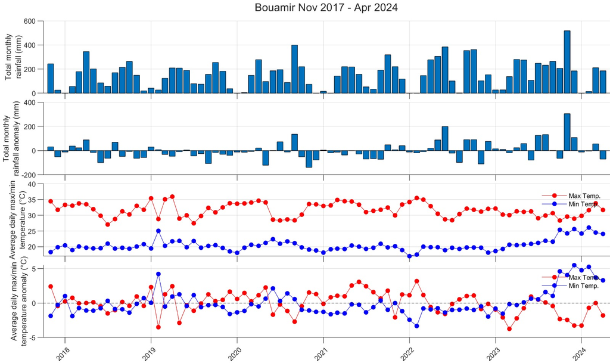

## Soil sampling

- Existing dataset for the four older plot in Bouamir (but only one sample per plot)

| plot_name | ph_soil | sand_content | clay_content | silt_content | organic_soil_carbon | nitrogen_soil_carbon |
| --- | --- | --- | --- | --- | --- | --- |
| bouamir001 | 3.99 | 37.90 | 45.96 | 16.14 | 2.02 | 0.19 |
| bouamir002 | 4.20 | 40.04 | 47.89 | 12.07 | 1.46 | 0.13 |
| bouamir003 | 4.53 | 38.04 | 47.89 | 14.07 | 1.07 | 0.10 |
| bouamir004 | 4.22 | 37.90 | 47.96 | 14.14 | 2.16 | 0.18 |

## Soil sampling

- Recently much more intense sampling took place for 6 plots in Mbalmayo. Sampling in Bouamir will take place in July. We plan to measure physical and chemical properties.

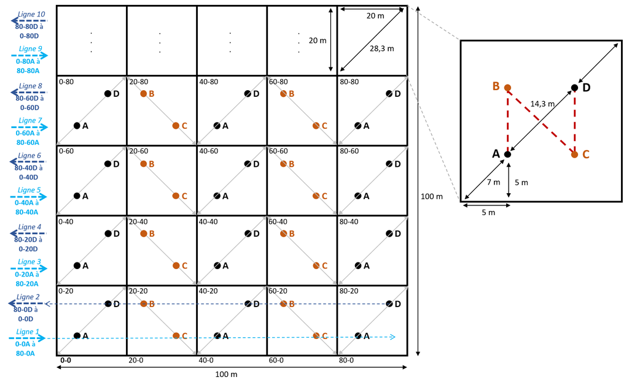

- Subgroup talk about soil can take place with David Bauman and myself and anybody interested (if anybody !)

## Soft traits sampling

- For one year, seven field mission (six in Mbalmayo and one in Bouamir), we measured soft traits for canopy trees (as well as species collected in plots).
- Climbers team (trained one year ago) to get branches from canopy (directly exposed to sunlight).
- Objectives are to sample as many species as possible, starting from the most frequent.
- Explore how traits covariation can be linked with phenological behaviours.

## Soft traits sampling

In short, three leaves per cohort (growth units of different ages) are sampled for LMA (at mesophyl, lamina and whole leaf scales), mesophyl thickness, SPAD chlorophyll concentration, leaf area.

Taking into account leaves cohorts imply a good understanding on how leaves develop –> See Patrick Heuret presentation on how morpho-anatomical markers can help to decipher growth units and growth rythmicity.

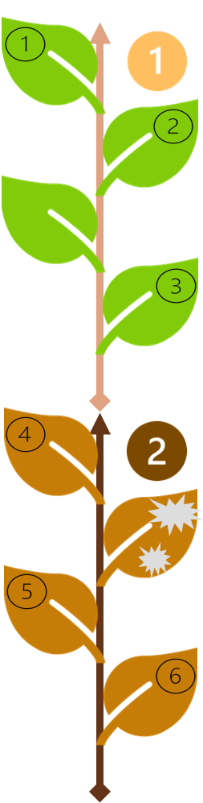

## Soft traits sampling

So far (ongoing work, some measurements still need to be processed) :

| trait | n |
| --- | --- |
| SPAD_chlorophyll_measurement | 933 |
| SPAD_chlorophyll_measurement_immature_leaves | 82 |
| leaf_area | 944 |
| lma_lamina_immature | 40 |
| lma_lamina_mature | 546 |
| lma_whole_leaf_immature | 5 |
| lma_whole_leaf_mature | 116 |
| mesophyl_thickness | 922 |
| mesophyl_thickness_immature_leaves | 81 |
| twig_specific_gravity | 260 |
| whole_leaf_area | 538 |

## Soft traits sampling

- 73 species have been sampled in **Mbalmayo**. 49.7% of the total species pool, but species that represent 87% of all canopy trees.
- 56 species have been sampled in **Bouamir**. 40.9% of the total species pool, but species that represent 75% of all canopy trees.

## Soft traits sampling

- Recent internship by Vincent Pearlstein to study how traits (morphological, spectral and chemical properties) vary with leaf age, and ultimately better understand how photosynthetic capacity vary with leaf ages.

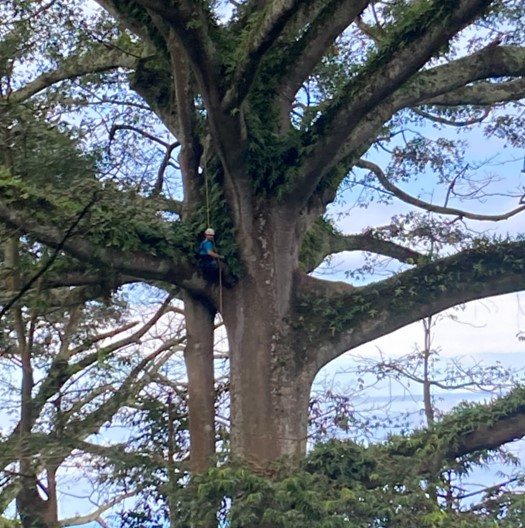

[figure not shown]

## Soft traits sampling

- 5 species were selected in Mbalmayo. Several individuals (33) of each species were sampled several times during 3 months (February to April). Soft traits in addition to spectrometer measurements.
- 768 leaves measured, 13 114 spectras (4038 measurements).
- Nitrogen and pigment concentrations will be available soon.
- Estimate leaf age based on drone surveys, not easy (manual estimation based on RGB images).
- Spectrometer used seemed to provide inconsistent measurements.

## Soft traits sampling

Subgroup talk for more in depth explanation of the protocol and datasets already available. Could help to select species for eco-physiological measures.

We should make sure protocol are similar to have comparable datasets.

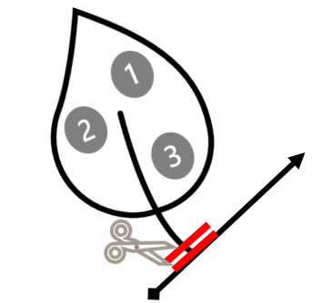

## Data management (Work package 1)

Gather, harmonize and share existing data to provide ground-truth estimates of multiple dimensions of tree diversity in the Congo Basin Forests.

First of all, gather and organize data in a relational database to at least make dataset comparable : the minimum is to have all data managed with a similar taxonomic framework. This is done for Mbalmayo and Bouamir, soon for Loundoungou. I can give access to those who want.

A second step is to make available and open aggregated data. We have a potential solution to generate static website using NIAMOTO, a python app to generate static web portal (see Dimitri presentation later).